# Homework 07

Use either R or Python.

## Question 1: LDA

Let’s start by estimating the components of LDA. From the lecture notes, for each target point $\mathbf{x}_0$, we find the class label $k$ with the largest score

$$\mathbf{x}_0^{\mathsf T}\boldsymbol{\Sigma}^{-1}\boldsymbol{\mu}_k
-\frac12\boldsymbol{\mu}_k^{\mathsf T}\boldsymbol{\Sigma}^{-1}\boldsymbol{\mu}_k
+\log\pi_k.$$

Thus, we need to estimate:

- the prior probabilities $\pi_k$;
- the mean vector (centroid) $\boldsymbol{\mu}_k$ for each class; and
- the pooled covariance matrix $\boldsymbol{\Sigma}$.

Use saheart.csv, the `SAheart` data from `ElemStatLearn`. The two classes are defined by `chd`, the coronary heart disease indicator. Use all nine other variables as numerical predictors, coding `famhist` as 1 for `Absent` and 2 for `Present`. The following code constructs an $n\times9$ predictor matrix $\mathbf{X}$ and an $n$-entry response vector $\mathbf{y}$, where $n$ is the number of observations.

**R**

```r
heart <- read.csv("data/saheart.csv")
heart$famhist <- factor(heart$famhist, levels = c("Absent", "Present"))
X <- data.matrix(heart[, names(heart) != "chd"])
y <- heart$chd
```

**Python**

```python
import pandas as pd

heart = pd.read_csv("data/saheart.csv")
heart["famhist"] = heart["famhist"].map({"Absent": 1, "Present": 2})
X = heart.drop(columns="chd").to_numpy()
y = heart["chd"].to_numpy()
```

1. Calculate the prior probabilities, class means, and pooled covariance matrix from these data. Use the pooled covariance denominator $n-K$ from the lecture, where $K=2$ is the number of classes.

```r
# Load the data
heart = read.csv("C:/Users/kates/.vscode/stat432-fall2026/homework/week-07/data/saheart.csv")

# Encode family history: Absent = 1, Present = 2
heart$famhist <- factor(
  heart$famhist,
  levels = c("Absent", "Present")
)

heart$famhist <- as.numeric(heart$famhist)

# Create predictor matrix X and response vector y
X <- data.matrix(heart[, names(heart) != "chd"])
y <- heart$chd

# Dimensions
n <- nrow(X)
p <- ncol(X)
classes <- sort(unique(y))
K <- length(classes)

dim(X)
```

```
[1] 462   9
```

```r
length(y)
```

```
[1] 462
```

```r
# 1. Calculate empirical prior probabilities
priors <- table(y) / n

print("Prior probabilities:")
```

```
[1] "Prior probabilities:"
```

```r
print(priors)
```

```
y
        0         1
0.6536797 0.3463203
```

```r
# 2. Calculate the mean vector for each class
means <- matrix(NA, nrow = K, ncol = p)

rownames(means) <- classes
colnames(means) <- colnames(X)

for (j in seq_along(classes)) {
  k <- classes[j]
  means[j, ] <- colMeans(X[y == k, , drop = FALSE])
}

print("Class means:")
```

```
[1] "Class means:"
```

```r
print(means)
```

```
       sbp  tobacco      ldl adiposity  famhist    typea  obesity  alcohol
0 135.4603 2.634735 4.344238  23.96911 1.317881 52.36755 25.73745 15.93136
1 143.7375 5.524875 5.487938  28.12025 1.600000 54.49375 26.62294 19.14525
       age
0 38.85430
1 50.29375
```

```r
# 3. Calculate the pooled covariance matrix
pooled_sum <- matrix(0, nrow = p, ncol = p)

for (k in classes) {
  X_k <- X[y == k, , drop = FALSE]
  mu_k <- means[as.character(k), ]

  centered <- sweep(X_k, 2, mu_k, "-")

  pooled_sum <- pooled_sum + t(centered) %*% centered
}

Sigma <- pooled_sum / (n - K)

print("Pooled covariance matrix:")
```

```
[1] "Pooled covariance matrix:"
```

```r
print(Sigma)
```

```
                  sbp    tobacco         ldl  adiposity    famhist        typea
sbp       405.4347786 14.5851882  4.58124834 49.1643582 0.33698819 -15.58772153
tobacco    14.5851882 19.2425564  0.76320271  7.5381093 0.01582050  -2.05730592
ldl         4.5812483  0.7632027  4.00058129  6.0326970 0.09185024   0.34459233
adiposity  49.1643582  7.5381093  6.03269701 56.7528931 0.43280832  -5.30956633
famhist     0.3369882  0.0158205  0.09185024  0.4328083 0.22583357   0.08112007
typea     -15.5877215 -2.0573059  0.34459233 -5.3095663 0.08112007  95.56564291
obesity    18.9388430  1.8334506  2.66005159 22.7078852 0.18402776   2.64006728
alcohol    64.4003517 20.5170451 -2.53290675 16.1190253 0.76846885   7.96003164
age        95.1338895 22.7654113  6.47892049 60.5086715 0.99736251 -20.27833492
             obesity     alcohol         age
sbp       18.9388430  64.4003517  95.1338895
tobacco    1.8334506  20.5170451  22.7654113
ldl        2.6600516  -2.5329068   6.4789205
adiposity 22.7078852  16.1190253  60.5086715
famhist    0.1840278   0.7684688   0.9973625
typea      2.6400673   7.9600316 -20.2783349
obesity   17.6154236   4.6893563  15.6969995
alcohol    4.6893563 598.2766133  27.8859413
age       15.6969995  27.8859413 184.1321373
```

```r
# Check dimensions
dim(means)  # 2 x 9
```

```
[1] 2 9
```

```r
dim(Sigma)  # 9 x 9
```

```
[1] 9 9
```

2. Use your estimated values to predict the label of each observation in the training data. These are in-sample fitted labels. Provide the confusion matrix, with observed classes in rows and predicted classes in columns. Check that the dimensions of your matrices and vectors match. Calculate the scores yourself for this part.

```r
# Invert the pooled covariance matrix
Sigma_inv <- solve(Sigma)

# Store the class mean vectors as columns
mean_matrix <- t(means)

# First term: X %*% Sigma_inv %*% mean_matrix
# Dimensions: (n x 9) %*% (9 x 9) %*% (9 x 2)
first_term <- X %*% Sigma_inv %*% mean_matrix

# Second term: one value per class
second_term <- numeric(K)

for (j in seq_along(classes)) {
  mu_k <- means[j, ]

  second_term[j] <- t(mu_k) %*% Sigma_inv %*% mu_k
}

# Third term: log prior probabilities
log_priors <- log(as.numeric(priors))

# Calculate scores for every observation and class
scores <- sweep(first_term, 2, 0.5 * second_term, "-")
scores <- sweep(scores, 2, log_priors, "+")

# Check dimensions: n x 2
dim(scores)
```

```
[1] 462   2
```

```r
# Predict the class with the largest score
predicted <- classes[max.col(scores, ties.method = "first")]

# Confusion matrix:
# Rows = observed classes
# Columns = predicted classes
confusion_manual <- table(
  Observed = factor(y, levels = classes),
  Predicted = factor(predicted, levels = classes)
)

print("Manual LDA confusion matrix:")
```

```
[1] "Manual LDA confusion matrix:"
```

```r
print(confusion_manual)
```

```
        Predicted
Observed   0   1
       0 258  44
       1  73  87
```

3. Perform the same LDA analysis using `MASS::lda` in R or `LinearDiscriminantAnalysis(solver="svd")` in Python, using the same numerical predictors and empirical class priors. Provide the confusion matrix. Do the results match?

```r
# Load MASS
library(MASS)

# Fit built-in LDA with empirical class priors
lda_fit <- lda(
  x = X,
  grouping = factor(y, levels = classes),
  prior = as.numeric(priors)
)

# Predict the training observations
lda_predictions <- predict(lda_fit, X)$class

# Confusion matrix
confusion_builtin <- table(
  Observed = factor(y, levels = classes),
  Predicted = factor(lda_predictions, levels = classes)
)

print("Built-in LDA confusion matrix:")
```

```
[1] "Built-in LDA confusion matrix:"
```

```r
print(confusion_builtin)
```

```
        Predicted
Observed   0   1
       0 258  44
       1  73  87
```

```r
# Compare the results
print("Do the confusion matrices match?")
```

```
[1] "Do the confusion matrices match?"
```

```r
print(all(confusion_manual == confusion_builtin))
```

```
[1] TRUE
```

```r
print("Do all individual predictions match?")
```

```
[1] "Do all individual predictions match?"
```

```r
print(all(predicted == as.numeric(as.character(lda_predictions))))
```

```
[1] TRUE
```

## Question 2: QDA and marginal screening

In the lecture, ordinary QDA could not be fitted to the handwritten digit sample because its within-class covariance matrices were singular. Let’s consider selecting fewer variables and see whether this helps. For this question, use the full zip-train.csv.gz as the training data and zip-test.csv.gz as the test data, with all ten digit classes. These are the original `zip.train` and `zip.test` data from `ElemStatLearn`. Each file has no header: the first column is the digit label and the remaining 256 columns are pixel values.

Instead of using all 256 predictors, select the 40 with the largest marginal variances in the training data. Here, marginal variance means the variance of one pixel across all training observations. Use the original pixel values without standardizing them, and retain the same selected predictors in the test data.

Use `MASS::qda` in R or `QuadraticDiscriminantAnalysis(tol=1e-8)` in Python.

1. Fit QDA using these 40 predictors and report the test confusion matrix, with observed classes in rows and predicted classes in columns. Also report the test misclassification rate.

```r
train <- read.csv("C:/Users/kates/.vscode/stat432-fall2026/homework/week-07/data/zip-train.csv.gz")
test <- read.csv("C:/Users/kates/.vscode/stat432-fall2026/homework/week-07/data/zip-test.csv.gz")

# First column = digit label; remaining columns = 256 pixels
y_train <- train[[1]]
y_test <- test[[1]]

X_train <- as.matrix(train[, -1])
X_test <- as.matrix(test[, -1])

# Check dimensions
dim(X_train)
```

```
[1] 7290  256
```

```r
dim(X_test)
```

```
[1] 2006  256
```

```r
# Find the 40 pixels with the largest marginal variances
pixel_vars <- apply(X_train, 2, var)
selected_40 <- order(pixel_vars, decreasing = TRUE)[1:40]

# Use the same selected pixels in training and test data
X_train_40 <- X_train[, selected_40, drop = FALSE]
X_test_40 <- X_test[, selected_40, drop = FALSE]

# Fit QDA
library(MASS)

qda_40 <- qda(
  x = X_train_40,
  grouping = factor(y_train, levels = 0:9),
  tol = 1e-8
)

# Predict the test observations
pred_40 <- predict(qda_40, X_test_40)$class
# Confusion matrix: observed classes in rows,
# predicted classes in columns
confusion_40 <- table(
  Observed = factor(y_test, levels = 0:9),
  Predicted = factor(pred_40, levels = 0:9)
)

print("Confusion matrix: 40 predictors")
```

```
[1] "Confusion matrix: 40 predictors"
```

```r
print(confusion_40)
```

```
        Predicted
Observed   0   1   2   3   4   5   6   7   8   9
       0 319   0  24   6   2   2   1   0   5   0
       1   0 238   5   0  11   0   7   0   3   0
       2   8   0 168   8   8   3   0   0   3   0
       3   5   0   4 128   0  14   0   0  15   0
       4   0   2  13   1 150   1   0   1   7  25
       5  12   0   3   5   1 131   0   0   6   2
       6   0   0   8   0   1   8 148   0   5   0
       7   1   0   6   1   6   0   0 124   2   7
       8   1   0  10  12   3   2   0   0 137   1
       9   0   0   1   2   7   1   1   4   9 151
```

```r
# Test misclassification rate
error_40 <- mean(as.character(pred_40) != as.character(y_test))

print("Test misclassification rate: 40 predictors")
```

```
[1] "Test misclassification rate: 40 predictors"
```

```r
print(error_40)
```

```
[1] 0.1555334
```

2. Does the method work? Why do you think it works or does not work? The method works because by selecting the 40 predictors with the largest marginal variances, we reduce the dimensionality of the data and avoid issues with singular covariance matrices that can occur when using all 256 predictors. The selected predictors are likely to contain more discriminative information about the classes, which helps QDA perform better. Additionally, reducing the number of predictors helps mitigate overfitting and improves generalization to the test data.
3. Repeat the analysis using the 10 predictors with the largest marginal variances in the training data. How does the test misclassification rate compare with the 40-predictor version? Why do you think this happens?

```r
# Find the 10 pixels with the largest variances
selected_10 <- order(pixel_vars, decreasing = TRUE)[1:10]

# Select the same pixels in training and test data
X_train_10 <- X_train[, selected_10, drop = FALSE]
X_test_10 <- X_test[, selected_10, drop = FALSE]

# Fit QDA using 10 predictors
qda_10 <- qda(
  x = X_train_10,
  grouping = factor(y_train, levels = 0:9),
  tol = 1e-8
)

# Predict test labels
pred_10 <- predict(qda_10, X_test_10)$class
# Confusion matrix
confusion_10 <- table(
  Observed = factor(y_test, levels = 0:9),
  Predicted = factor(pred_10, levels = 0:9)
)

print("Confusion matrix: 10 predictors")
```

```
[1] "Confusion matrix: 10 predictors"
```

```r
print(confusion_10)
```

```
        Predicted
Observed   0   1   2   3   4   5   6   7   8   9
       0 298   0  11   1   1  16  28   4   0   0
       1   0 241  10   0   3   1   1   0   2   6
       2  19   2  95  14  14   3  22  21   5   3
       3   5   0   6 103   3  42   0   0   7   0
       4   1   5  14   0  95   2   4  15  17  47
       5  15   0   6  25   4  96   4   2   8   0
       6  41   0  15   4   0  18  78   7   5   2
       7   4   1   6   0   6   0   1 122   0   7
       8   1   2  11  36  12  11   4   1  74  14
       9   0   2   9   2  20   0   0  16  10 117
```

```r
# Test misclassification rate
error_10 <- mean(as.character(pred_10) != as.character(y_test))

print("Test misclassification rate: 10 predictors")
```

```
[1] "Test misclassification rate: 10 predictors"
```

```r
print(error_10)
```

```
[1] 0.3424726
```

```r
# Compare both models
cat("40-predictor error:", error_40, "\n")
```

```
40-predictor error: 0.1555334
```

```r
cat("10-predictor error:", error_10, "\n")
```

```
10-predictor error: 0.3424726
```

```r
cat("Difference (10 predictors - 40 predictors):",
    error_10 - error_40, "\n")
```

```
Difference (10 predictors - 40 predictors): 0.1869392
```

It is worse with 10 predictors because reducing the number of predictors further may lead to loss of important discriminative information that helps distinguish between the classes. While selecting the top 40 predictors captures more variance and potentially more relevant features, using only 10 predictors may not provide enough information for QDA to effectively separate the classes, resulting in a higher misclassification rate.

## Question 3: Compare LDA and QDA

In this simulation, we will study how the relative performance of LDA and QDA changes with the true covariance structure. The parameter $\rho$ controls the distribution from which we generate the data; it is not a tuning parameter of LDA or QDA.

Consider a classification problem with two equally likely classes, labeled 1 and 2, and $p=10$ covariates. The first two covariates have the class-conditional distributions

$$\begin{pmatrix}X_1\\X_2\end{pmatrix}\mid Y=1
\sim N_2\left(
\begin{pmatrix}-1\\0\end{pmatrix},
\begin{pmatrix}1&\rho\\\rho&1\end{pmatrix}
\right),$$

$$\begin{pmatrix}X_1\\X_2\end{pmatrix}\mid Y=2
\sim N_2\left(
\begin{pmatrix}1\\0\end{pmatrix},
\begin{pmatrix}1&-\rho\\-\rho&1\end{pmatrix}
\right).$$

In both classes, the remaining eight covariates are independent standard normal variables, independent of the first two. Consider

$$\rho\in\{0,0.2,0.4,0.6,0.8,0.9\}.$$

For each value of $\rho$, generate 100 training observations and 1,000 independent test observations from each class. Fit ordinary LDA and QDA using all 10 covariates and equal class priors. Estimate the class means from the training data, with one pooled covariance matrix for LDA and one full covariance matrix per class for QDA. Set a random seed and report it.

1. Generate one dataset for each value of $\rho$. Fit both methods and calculate their test misclassification rates. Within each setting, use the same training and test observations for the two methods.

```r
library(MASS)

# Set and report the random seed
set.seed(43207)
cat("Random seed: 43207\n")
```

```
Random seed: 43207
```

```r
# Values of rho
rho_values <- c(0, 0.2, 0.4, 0.6, 0.8, 0.9)

# Generate observations for one class
generate_class <- function(n, mu, rho, class_label) {

  # Correlation structure for the first two predictors
  Sigma_2 <- matrix(
    c(1, rho,
      rho, 1),
    nrow = 2
  )

  # Generate the first two correlated predictors
  Z <- matrix(rnorm(n * 2), nrow = n, ncol = 2)
  X_first2 <- sweep(Z %*% chol(Sigma_2), 2, mu, "+")

  # Generate eight independent noise predictors
  X_noise <- matrix(rnorm(n * 8), nrow = n, ncol = 8)

  X <- cbind(X_first2, X_noise)
  y <- rep(class_label, n)

  list(X = X, y = y)
}

# Generate one training and test dataset for a given rho
generate_data <- function(rho) {

  # Class 1: correlation rho
  train_1 <- generate_class(100, c(-1, 0), rho, 1)
  test_1  <- generate_class(1000, c(-1, 0), rho, 1)

  # Class 2: correlation -rho
  train_2 <- generate_class(100, c(1, 0), -rho, 2)
  test_2  <- generate_class(1000, c(1, 0), -rho, 2)

  list(
    X_train = rbind(train_1$X, train_2$X),
    y_train = factor(c(train_1$y, train_2$y), levels = 1:2),
    X_test = rbind(test_1$X, test_2$X),
    y_test = factor(c(test_1$y, test_2$y), levels = 1:2)
  )
}

# Fit both models and calculate test errors
fit_compare <- function(dat) {

  # LDA: shared covariance matrix
  lda_fit <- lda(
    x = dat$X_train,
    grouping = dat$y_train,
    prior = c(0.5, 0.5)
  )

  lda_pred <- predict(lda_fit, dat$X_test)$class
  lda_error <- mean(lda_pred != dat$y_test)

  # QDA: separate covariance matrices
  qda_fit <- qda(
    x = dat$X_train,
    grouping = dat$y_train,
    prior = c(0.5, 0.5)
  )

  qda_pred <- predict(qda_fit, dat$X_test)$class
  qda_error <- mean(qda_pred != dat$y_test)

  c(LDA = lda_error, QDA = qda_error)
}

# Part 1: one dataset for each rho
results_once <- data.frame(
  rho = rho_values,
  LDA_error = NA_real_,
  QDA_error = NA_real_
)

for (i in seq_along(rho_values)) {

  dat <- generate_data(rho_values[i])
  errors <- fit_compare(dat)

  results_once$LDA_error[i] <- errors["LDA"]
  results_once$QDA_error[i] <- errors["QDA"]
}

print(results_once)
```

```
  rho LDA_error QDA_error
1 0.0    0.1800    0.1975
2 0.2    0.1850    0.2030
3 0.4    0.1725    0.1945
4 0.6    0.1595    0.1810
5 0.8    0.1675    0.1280
6 0.9    0.1770    0.1080
```

2. At each fixed value of $\rho$, repeat the experiment 50 times, generating new training and test observations in each repetition. Plot average test error against $\rho$ in one figure, with one curve for LDA and one for QDA. These curves compare performance across different data-generating distributions.

```r
# Part 2: repeat each setting 50 times
n_reps <- 50

results_repeated <- data.frame(
  rho = rho_values,
  LDA_error = NA_real_,
  QDA_error = NA_real_
)

# Store the individual errors for each repetition
all_errors <- array(
  NA_real_,
  dim = c(length(rho_values), n_reps, 2),
  dimnames = list(
    rho = rho_values,
    repetition = NULL,
    method = c("LDA", "QDA")
  )
)

for (i in seq_along(rho_values)) {

  for (r in 1:n_reps) {

    # New training and test data for each repetition
    dat <- generate_data(rho_values[i])

    errors <- fit_compare(dat)

    all_errors[i, r, "LDA"] <- errors["LDA"]
    all_errors[i, r, "QDA"] <- errors["QDA"]
  }

  # Average test errors over the 50 repetitions
  results_repeated$LDA_error[i] <-
    mean(all_errors[i, , "LDA"])

  results_repeated$QDA_error[i] <-
    mean(all_errors[i, , "QDA"])
}

print(results_repeated)
```

```
  rho LDA_error QDA_error
1 0.0   0.16862   0.19488
2 0.2   0.16981   0.19640
3 0.4   0.17004   0.19472
4 0.6   0.16782   0.17482
5 0.8   0.16551   0.13499
6 0.9   0.17027   0.10010
```

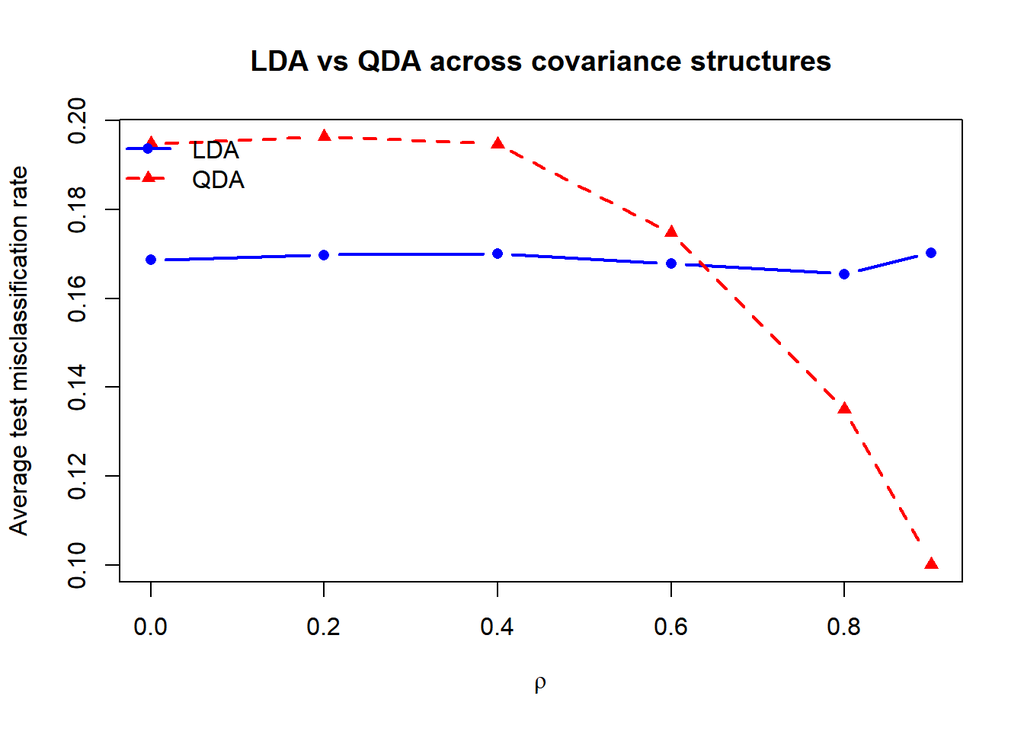

```r
# Plot both curves in one figure
matplot(
  results_repeated$rho,
  results_repeated[, c("LDA_error", "QDA_error")],
  type = "b",
  pch = c(16, 17),
  lty = c(1, 2),
  lwd = 2,
  col = c("blue", "red"),
  xlab = expression(rho),
  ylab = "Average test misclassification rate",
  main = "LDA vs QDA across covariance structures"
)

legend(
  "topleft",
  legend = c("LDA", "QDA"),
  col = c("blue", "red"),
  pch = c(16, 17),
  lty = c(1, 2),
  lwd = 2,
  bty = "n"
)
```

3. Compare the two methods at small and large values of $\rho$. How does changing the true covariance structure affect their relative performance? Explain the pattern using their covariance assumptions and the bias-variance trade-off. How can the eight noise covariates affect performance even though they contain no information about the class label?

When rho is small, the covariance structure of the two classes is similar, and LDA performs better because it assumes a shared covariance matrix, which reduces variance in the estimates. QDA, on the other hand, estimates separate covariance matrices for each class, which can lead to higher variance in the estimates when the true covariance structures are similar. The eight noise predictors do not contain information about the class label, but they can still affect classification performance. Both methods must estimate parameters involving these predictors, which introduces estimation uncertainty. This can make classification less accurate, particularly for QDA, which estimates more covariance parameters than LDA. This illustrates the bias-variance trade-off: LDA has a stronger assumption that can introduce bias when the covariance matrices differ, while QDA is more flexible but can have higher variance.

## Question 4: Create and use an LDA/QDA analysis skill

In Homework 5, you created a skill for formatting plots. Now create a reusable skill that guides an AI agent through an LDA/QDA analysis and produces a concise statistical report. You may work with AI to design and write the skill; you do not need to write every line yourself.

1. **Define the skill.** Write a single `SKILL.md` file no larger than **5 KB (5,000 bytes)**. Define the agent’s behavior, analysis guidelines, and expected report structure. Keep the skill independent of this question: provide the dataset, response, and predictors separately when invoking it. The skill may guide the agent to explore lower-dimensional representations, such as principal component analysis (PCA), or to blend the class probabilities predicted by LDA and QDA. Keep all classifiers based on LDA, QDA, or their combination. Configure the skill to load **only when you explicitly invoke it**. Use your AI tool’s invocation settings, or keep the file outside automatically loaded skill folders and supply it only in an explicit request.

Your skill must require a clearly readable analysis report of **at most one printed page**, containing a figure, a table, and numerical model-fitting results. You may specify the type and style of figures and tables you want the AI to produce. All instructions in the skill must be independent of the actual dataset, its variable names, and its observed results. The report should briefly describe the candidate models, the cross-validation procedure and results, the selected model, and its estimated prediction error. It should explain the main findings and any limitations.

2. **Apply the skill.** Explicitly invoke your skill to analyze the `SAheart` data from Question 1, using the same response and predictor coding. Ask the agent to seek the best predictive performance within the LDA/QDA methods allowed by your skill. Include ordinary LDA and QDA as comparisons; the extensions above are optional. Reserve a test set before choosing models. Use the same cross-validation folds within the training data to compare candidates and select any settings. Estimate any preprocessing, including an embedding, using only the training observations in each fold. Refit the selected model and preprocessing on all training observations, then evaluate the fitted classifier once on the reserved test set. Use misclassification rate to compare performance, and report your random seed.
3. **Review and submit.** Check the agent’s analysis and make any skill revisions using only training and cross-validation results. Append the final one-page analysis report and the complete contents of your `SKILL.md` to your homework report. State the file size and briefly explain how you enabled explicit invocation, including the prompt used to apply the skill. The one-page limit applies to the analysis report; the appended skill and this explanation are outside that limit.

Your skill and analysis report will be reviewed and graded by other students through peer evaluation.

I need to ask about this because I don’t know what to do.